# R HW 01: Hello R!

Author

Robsen Gelalcha

Published

September 8, 2026

```r
library(tidyverse)
library(datasauRus)
```

# Exercise 1

A data frame with 1846 rows and 3 variables(rows):

- dataset: indicates which dataset the data are from
- x: x-values
- y: y-values

# Exercise 2

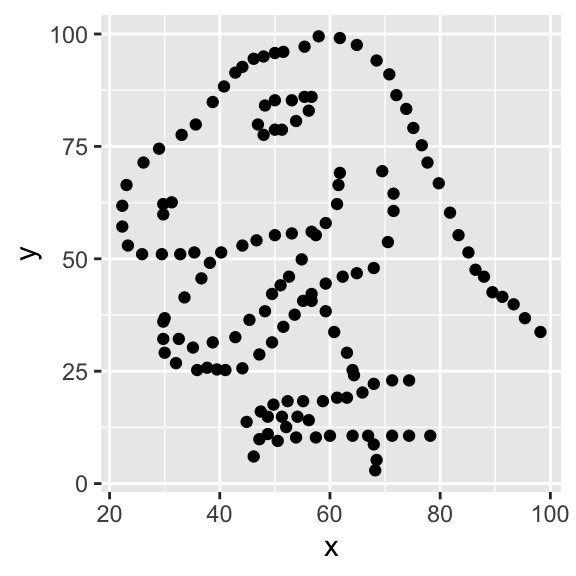

```r
dino_data <- datasaurus_dozen |>
  filter(dataset == "dino")
ggplot(data = dino_data, mapping = aes(x = x, y = y)) +
  geom_point()
```

```r
dino_data |>
  summarize(r = cor(x, y))
```

```
# A tibble: 1 × 1
        r
    <dbl>
1 -0.0645
```

# Exercise 3

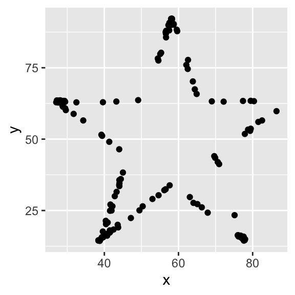

```r
star_data <- datasaurus_dozen |>
  filter(dataset == "star")
ggplot(data = star_data, mapping = aes(x = x, y = y)) +
  geom_point()
```

```r
star_data |>
  summarize(r = cor(x, y))
```

```
# A tibble: 1 × 1
        r
    <dbl>
1 -0.0630
```

> Based on the plot, I expect a close to zero correlation. The values are all over the place and they don’t follow a singular pattern.

> The two r values are almost the same.

# Exercise 4

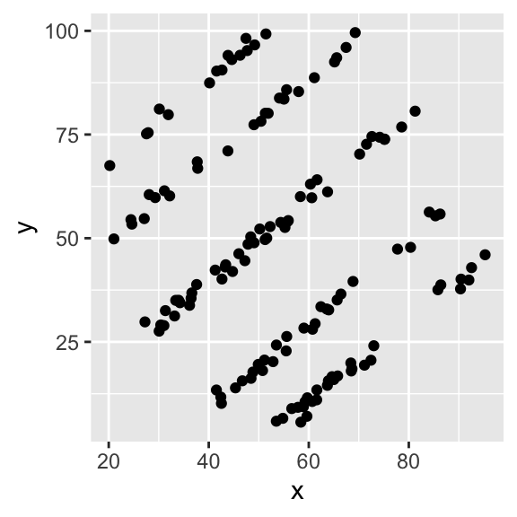

```r
slant_up_data <- datasaurus_dozen |>
  filter(dataset == "slant_up")
ggplot(data = slant_up_data, mapping = aes(x = x, y = y)) +
  geom_point()
```

```r
slant_up_data |>
  summarize(r = cor(x, y))
```

```
# A tibble: 1 × 1
        r
    <dbl>
1 -0.0686
```

> The plotted dataset looks like a series of parallel lines. Since the plots seem to be slanting up, I expect a positive correlation.

> The coefficient is close to zero. The value is less than zero, therefore less than what I expected. The correlation captures that there is a negative linear relationship between the variables, but does not describe the scattered nature of the dataset. And therefore we cannot infer anything of value only based on the correlation.

# Exercise 5

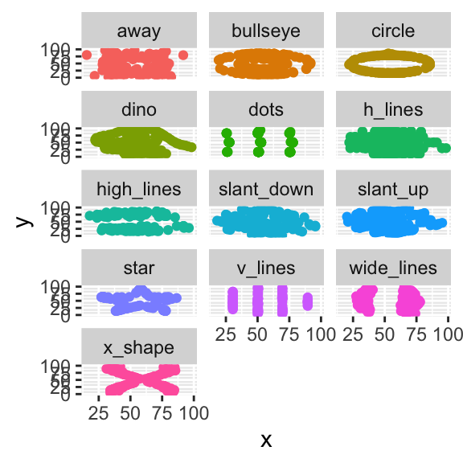

```r
ggplot(datasaurus_dozen, aes(x = x, y = y, color = dataset))+
  geom_point()+
  facet_wrap(~ dataset, ncol = 3) +
  theme(legend.position = "none")
```

```r
datasaurus_dozen |>
  group_by(dataset) |>
  summarize(r = cor(x, y))
```

```
# A tibble: 13 × 2
   dataset          r
   <chr>        <dbl>
 1 away       -0.0641
 2 bullseye   -0.0686
 3 circle     -0.0683
 4 dino       -0.0645
 5 dots       -0.0603
 6 h_lines    -0.0617
 7 high_lines -0.0685
 8 slant_down -0.0690
 9 slant_up   -0.0686
10 star       -0.0630
11 v_lines    -0.0694
12 wide_lines -0.0666
13 x_shape    -0.0656
```

> None of the correlations are significant enough; they’re close to zero. We can understand that we cannot enforce linear relationships on datasets.

# Reflection prompts

*Respond to each of the following after you have completed all exercises in this assignment*

*(RP1): What were the main concepts covered in this assignment?*

> Using RStudio and Quarto, Scatterplots and correlation coefficients.

*(RP2): What’s one thing you understand better after completing these exercises?*

> R language basics and how to navigate RStudio.

*(RP3): What exercise(s) gave you the most trouble? What was difficult about them/where did you get stuck?*

> The first exercise was confusing as I wasn’t sure if variables and rows were different